# Bias vs. Noise

University of San Francisco

Matt Meister

## Bias vs Noise

In statistics, the terms **bias** and **noise** refer to very specific things.

**Bias**:

- *Systematic* errors that *consistently* push measurements or estimates away from the true value
- It is *predictable*, and often stems from flaws in the measurement process or the sampling method.
- Bias tends to push measurements or estimates in a particular direction, either overestimating or underestimating the true value.

**Noise**:

- Randomness or fluctuations in data that *can’t be attributed to a systematic cause*
- Unpredictable. Can result from various sources, including measurement errors, and chance.
- Noise doesn’t consistently push data in one direction but adds random fluctuations around the true value.

## Bias vs Noise

How we handle each also differs:

- **Bias:**
  - Usually involves identifying and eliminating or reducing sources of systematic error.
  - Techniques such as calibration, randomization, and careful study design can help mitigate bias.
- **Noise:**
  - Inherently random and cannot be eliminated entirely.
  - Techniques like averaging, statistical tests, and increasing sample sizes reduce the impact of noise.

# Noise

“Why isn’t having a small sample size a source of bias?”

## Noise

*“Why isn’t having a small sample size a source of bias?”*

Read in the data `customerData.csv`

```r
customerData <- read.csv("customerData.csv")
```

Let’s treat this full data set of 1000 observations as the **population** – the entire set of people we are interested in.

In the **population**, what is the mean of `income`?

```r
mean(customerData$income)
```

```
[1] 65476.08
```

## Noise

Imagine we did not know this number for the population

- We could only **estimate** it by surveying a sample of people.
- Take a random subset of 10 observations by running this code:

```r
sample.size <- 10

customerDataSmall <- customerData[
  sample(x = 1:nrow(customerData),
         size = sample.size,
         replace = F),
  ]
```

## Noise

If you did not know the population average of `income`, how would you estimate it with your survey sample?

- You would see what the mean in the sample is!

```r
mean(customerDataSmall$income)
```

```
[1] 64266.1
```

That sample estimate is going to be **noisy**

- It’s going to vary from sample to sample around the **population average**
  - *“true mean”*

## Noise

That sample estimate is going to be **noisy**

- It’s going to vary from sample to sample around the **population average**.
- If everyone in the class had their own sample (which you do), what might your different estimates look like?

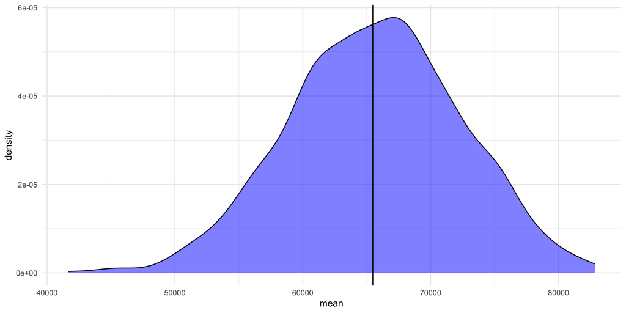

## Noise

Are these estimates **biased**?

- Are they more likely to be above or below the true mean?

% above:

```r
sum( # Sum of the logical argument
  sample.results$mean > mean(customerData$income))/ # Is the sample mean > than the pop?
  nsims
```

```
[1] 0.51
```

% below:

```r
sum( # Sum of the logical argument
  sample.results$mean < mean(customerData$income))/ # Is the sample mean > than the pop?
  nsims
```

```
[1] 0.49
```

## Noise

With a small sample, our results are not more likely to fall on one side of the true mean than the other.

- As long as our data don’t have crazy outliers!!

What is the benefit of larger samples, then?

- Precision!
- How far off were our estimates, on average?

```r
mean(abs(sample.results$mean - mean(customerData$income))) |>
  round(2)
```

```
[1] 5357.99
```

## Noise

Let’s try with samples of 20:

```r
sample.size <- 20

customerDataSmall <- customerData[
  sample(x = 1:nrow(customerData),
         size = sample.size,
         replace = F),
  ]

mean(customerDataSmall$income)
```

```
[1] 70132.8
```

## Noise

Let’s try with samples of 20:

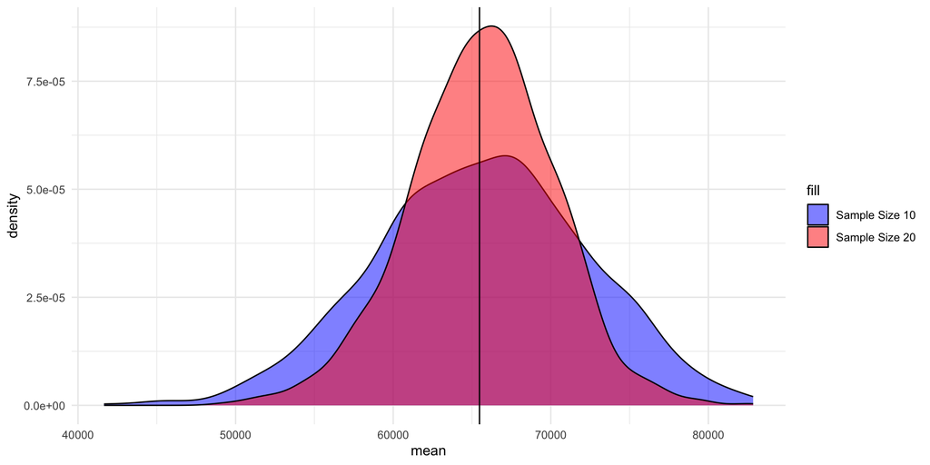

## Noise

Let’s try with samples of 20:

- How far off was our estimate, on average?

```r
mean(abs(sample.results[sample.results$sample.size==20,'mean'] - mean(customerData$income))) |>
  round(2)
```

```
[1] 3638.14
```

## Noise

Let’s try with samples of 100:

```r
sample.size <- 100

customerDataSmall <- customerData[
  sample(x = 1:nrow(customerData),
         size = sample.size,
         replace = F),
  ]

mean(customerDataSmall$income)
```

```
[1] 66418.28
```

## Noise

Let’s try with samples of 100:

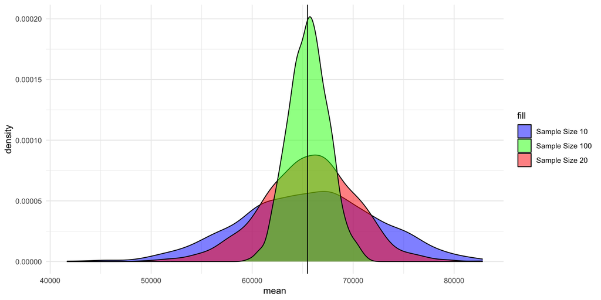

## Noise

Let’s try with samples of 100:

- How far off was our estimate, on average?

```r
mean(abs(sample.results[sample.results$sample.size==100,'mean'] - mean(customerData$income))) |>
  round(2)
```

```
[1] 1570.13
```

## Noise

Conclusion:

- Noise is **random error**
- It causes our estimates to bounce around the true/population mean
- Makes our estimates imprecise
- But it doesn’t push them in one direction or another

Bias on the other hand…

# Bias

Is bad…er

## Bias

- *Systematic* errors that *consistently* push measurements or estimates away from the true value
- It is *predictable*, and often stems from flaws in the measurement process or the sampling method.
- Bias tends to push measurements or estimates in a particular direction, either overestimating or underestimating the true value.
- Is **not** made better by increasing sample sizes

## Bias

Let’s imagine that instead of estimating `income` with a **random** sample of 10/20/100 people, we sent out a survey, and got 10 responses.

- But young people were more likely to respond

```r
sample.size <- 10

under30 <- customerData[customerData$age <= 29,]

customerDataSmall <- under30[
  sample(x = 1:nrow(under30),
         size = sample.size,
         replace = F),
  ]
```

## Bias

What is our estimate of `income` from these samples?

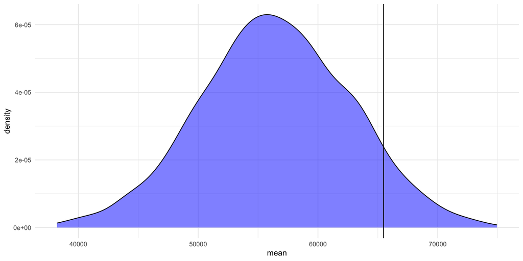

## Bias

Are these estimates **biased**?

- Are they more likely to be above or below the true mean?

% above:

```r
sum( # Sum of the logical argument
  sample.results$mean > mean(customerData$income))/ # Is the sample mean > than the pop?
  nrow(sample.results)
```

```
[1] 0.071
```

% below:

```r
sum( # Sum of the logical argument
  sample.results$mean < mean(customerData$income))/ # Is the sample mean > than the pop?
  nrow(sample.results)
```

```
[1] 0.929
```

## Bias

Let’s try with samples of 20:

```r
sample.size <- 20

customerDataSmall <- under30[
  sample(x = 1:nrow(under30),
         size = sample.size,
         replace = F),
  ]

mean(customerDataSmall$income)
```

```
[1] 57041.2
```

## Bias

Let’s try with samples of 20:

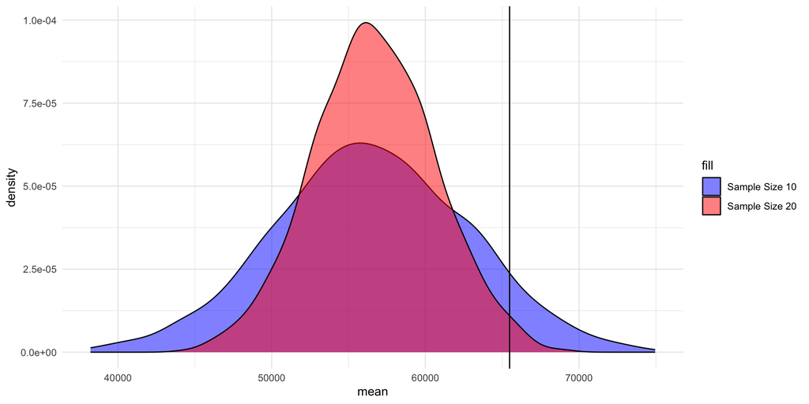

## Bias

Are these estimates **biased**?

- Are they more likely to be above or below the true mean?

% above:

```r
sum( # Sum of the logical argument
  sample.results$mean > mean(customerData$income))/ # Is the sample mean > than the pop?
  nrow(sample.results)
```

```
[1] 0.042
```

% below:

```r
sum( # Sum of the logical argument
  sample.results$mean < mean(customerData$income))/ # Is the sample mean > than the pop?
  nrow(sample.results)
```

```
[1] 0.958
```

## Bias

Let’s try with samples of 100:

```r
sample.size <- 100

customerDataSmall <- under30[
  sample(x = 1:nrow(under30),
         size = sample.size,
         replace = F),
  ]

mean(customerDataSmall$income)
```

```
[1] 56206.99
```

## Bias

Let’s try with samples of 100:

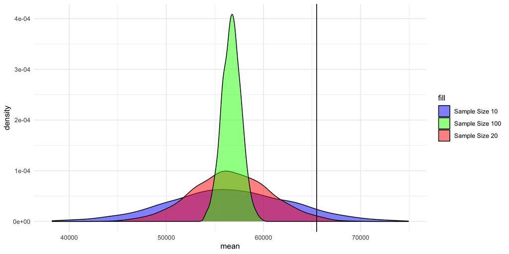

## Bias

Are these estimates **biased**?

- Are they more likely to be above or below the true mean?

% above:

```r
sum( # Sum of the logical argument
  sample.results$mean > mean(customerData$income))/ # Is the sample mean > than the pop?
  nrow(sample.results)
```

```
[1] 0.028
```

% below:

```r
sum( # Sum of the logical argument
  sample.results$mean < mean(customerData$income))/ # Is the sample mean > than the pop?
  nrow(sample.results)
```

```
[1] 0.972
```

## Bias

Conclusion:

- Bias is **not** random error
- It causes our estimates to be higher **or** lower than the true/population mean
- Makes our estimates **predictably wrong**
- It does not get better with sample size